# Omy_Klamath_Genotype_Frequencies

Kevin Olsen

2024-11-07

```r
library(kableExtra)
library(gt)
library(gtsummary)
library(knitr)
library(khroma)
library(adegenet)
library(magrittr)
library(tidyverse)
library(splitstackshape)
library(ggplot2)
```

Load quality filtered, location adjusted, and HWE/LD thinned markerset.

```r
load("C:/Users/olsenk2/OneDrive - Oregon State University/Desktop/Omy_klamath/Jan_2024_analyses/reproducible/Omykiss_Klamath_fullmarkerset_corrected_locations_Jan_2024_genos.R")
```

Update the location code name of Oak Hatchery to Klamath Hatchery.

```r
full_markerset %<>%
  mutate(location_code = case_when(location_code %in% c('OAKH') ~ 'KHAT',
                                   TRUE ~ as.character(location_code)
  ))
```

Revert the Omy-5 marker names to their original names (i.e., remove “Pearse” from the marker names).

```r
colnames(full_markerset)[95:100]<-c("OmyR14589", "OmyR19198", "OmyR24370", "OmyR33562", "OmyR40252", "OmyR40319")
```

Reset order of locations to match the numbering in Tables 1 & 2 and the map (Fig. 1).

```r
##Set order of locations##
full_markerset %<>%
  mutate(location_number = case_when(location_code %in% c('HAYF') ~ '10',
                                     location_code %in% c('SALT') ~ '7',
                                     location_code %in% c('EFHF') ~ '8',
                                     location_code %in% c('POTA') ~ '9',
                                     location_code %in% c('RSCH') ~ '6',
                                     location_code %in% c('ELTP') ~ '5',
                                     location_code %in% c('JCNW') ~ '1',
                                     location_code %in% c('GROU') ~ '3',
                                     location_code %in% c('UDWD') ~ '4',
                                     location_code %in% c('MOSQ') ~ '2',
                                     location_code %in% c('HORS') ~ '18',
                                     location_code %in% c('RUSH') ~ '19',
                                     location_code %in% c('GARD') ~ '17',
                                     location_code %in% c('CLAR') ~ '15',
                                     location_code %in% c('PLUM') ~ '14',
                                     location_code %in% c('BKBR') ~ '13',
                                     location_code %in% c('METH_03') ~ '12',
                                     location_code %in% c('METH') ~ '12',
                                     location_code %in% c('KNOW') ~ '11',
                                     location_code %in% c('TAYL') ~ '16',
                                     location_code %in% c('SHAS') ~ '20',
                                     location_code %in% c('BOGS') ~ '21',
                                     location_code %in% c('LJNY') ~ '22',
                                     location_code %in% c('UJNY_00') ~ '23',
                                     location_code %in% c('UJNY') ~ '23',
                                     location_code %in% c('BEAV') ~ '24',
                                     location_code %in% c('COLD') ~ '25',
                                     location_code %in% c('SHOV') ~ '26',
                                     location_code %in% c('BYPR_00') ~ '28',
                                     location_code %in% c('BYPR') ~ '28',
                                     location_code %in% c('PEAR') ~ '27',
                                     location_code %in% c('KENO_00') ~ '29',
                                     location_code %in% c('KENO') ~ '29',
                                     location_code %in% c('SPCR_00') ~ '30',
                                     location_code %in% c('SPCR') ~ '30',
                                     location_code %in% c('UKLA') ~ '31',
                                     location_code %in% c('DENN') ~ '32',
                                     location_code %in% c('MOSS') ~ '33',
                                     location_code %in% c('CHER_00') ~ '34',
                                     location_code %in% c('CHER') ~ '34',
                                     location_code %in% c('SEVN') ~ '35',
                                     location_code %in% c('AGNC') ~ '36',
                                     location_code %in% c('TECH') ~ '37',
                                     location_code %in% c('FORT') ~ '38',
                                     location_code %in% c('WOOD') ~ '39',
                                     location_code %in% c('ANNI') ~ '40',
                                     location_code %in% c('PINE') ~ '41',
                                     location_code %in% c('SCFA') ~ '42',
                                     location_code %in% c('SCSU_00') ~ '42',
                                     location_code %in% c('SCSU') ~ '42',
                                     location_code %in% c('SUNY') ~ '43',
                                     location_code %in% c('KNAP') ~ '44',
                                     location_code %in% c('UWIL') ~ '45',
                                     location_code %in% c('SFTC_00') ~ '48',
                                     location_code %in% c('SFTC') ~ '48',
                                     location_code %in% c('ROKS_00') ~ '49',
                                     location_code %in% c('ROKS') ~ '49',
                                     location_code %in% c('BTTY') ~ '47',
                                     location_code %in% c('PASY_00') ~ '51',
                                     location_code %in% c('PASY') ~ '51',
                                     location_code %in% c('LONG_00') ~ '50',
                                     location_code %in% c('LONG') ~ '50',
                                     location_code %in% c('FIVE_00') ~ '52',
                                     location_code %in% c('FIVE') ~ '52',
                                     location_code %in% c('MRYL') ~ '53',
                                     location_code %in% c('NFSP_06') ~ '54',
                                     location_code %in% c('NFSP') ~ '54',
                                     location_code %in% c('PASP') ~ '55',
                                     location_code %in% c('WHIT') ~ '56',
                                     location_code %in% c('SFSP') ~ '57',
                                     location_code %in% c('KAMK') ~ '46',
                                     location_code %in% c('CHEW') ~ '58',
                                     location_code %in% c('FOST') ~ '59',
                                     location_code %in% c('KHAT') ~ '60'
  ))
```

Evaluate genotypic frequencies at the adult run timing marker Omy_RAD15709-53 on chromosome 28 across contemporary samples collected in the years 2015 - 2019 (Fig 5).

```r
##drop old collections 2000 - 2006##
contemp_full_markerset <- full_markerset %>%
  filter(! c(Year_Collected == "2000" | Year_Collected == "2003" | Year_Collected == "2006"))
```

Subset the dataframe to the sampling metadata and the Omy_RAD15709-53 marker.

```r
omy_53 <- contemp_full_markerset[, c(1:27, 176)]   ##Grab metadata in columns 1:27 and the marker Omy_RAD15709-53 in column 176
```

Put the rows of the dataframe in order according to the location number.

```r
##put rows in order of location number##
omy_53<-omy_53[order(as.numeric(as.character(omy_53$location_number))), ]

##Set order of locations##
omy_53$location_code<-factor(omy_53$location_code, levels = unique(omy_53$location_code))
```

Calculate genotypic frequencies for early (EE), heterozygous (EL), and late (LL) genotypes.

```r
ws_summary <- omy_53 %>%
  group_by(location_code) %>%
  summarize(n = n(), EE = sum(`Omy_RAD15709-53` == "AA") / n, EL = sum(`Omy_RAD15709-53` == "GA") / n, LL = sum(`Omy_RAD15709-53` == "GG") / n, Missing = sum(`Omy_RAD15709-53` == "00") / n)

ws_summary %<>%
  pivot_longer(cols = c(EE, EL, LL, Missing))

kable(ws_summary[1:10, ], col.names = c("location", "n", "Genotype", "Frequency"))
```

| location | n | Genotype | Frequency |
| --- | --- | --- | --- |
| JCNW | 54 | EE | 0.9629630 |
| JCNW | 54 | EL | 0.0370370 |
| JCNW | 54 | LL | 0.0000000 |
| JCNW | 54 | Missing | 0.0000000 |
| MOSQ | 14 | EE | 0.0000000 |
| MOSQ | 14 | EL | 0.0714286 |
| MOSQ | 14 | LL | 0.9285714 |
| MOSQ | 14 | Missing | 0.0000000 |
| GROU | 13 | EE | 0.0000000 |
| GROU | 13 | EL | 0.3076923 |

Make the genotypic frequency barplot. Note, the plot created in this R markdown file is compressed. Exporting will make the plot larger and all the location labels will be visible.

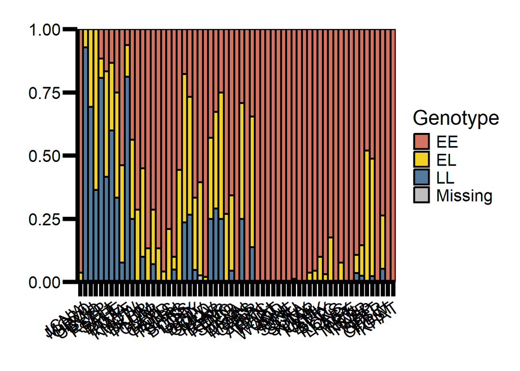

```r
ggplot(ws_summary, aes(fill = name, y = value, x = location_code)) +
  geom_bar(position = "stack", stat = "identity", width = 1, colour = 'black', size = 1.0, alpha = 0.85) +
  scale_fill_manual(values = c("coral3", "gold2", "steelblue4", "gray70"), name = "Genotype") +
  scale_x_discrete(expand = c(0.0, 0.0)) +
  scale_y_continuous(expand = c(0, 0)) +
  xlab("") +
  ylab("") +
  theme(panel.background = element_blank(),
        text = element_text(family = "sans"),
        plot.margin = margin(1, 0.5, 0.5, 0.5, "cm"),
        legend.title = element_text(size = 20),
        legend.text = element_text(size = 16),
        axis.line = element_line(size = 2, color = 'black'),
        axis.ticks = element_line(size = 2, color = 'black'),
        axis.ticks.length = unit(0.5, "cm"),
        axis.text.x = element_text(angle = 35, vjust = 0.95, hjust=1, size = 16, colour = 'black'),
        axis.text.y = element_text(size = 16, colour = 'black')
  )
```

Evaluate genotype frequencies at the anadromy/residency marker OmyR24370 on chromosome 5 across contemporary samples collected in the years 2015 - 2019 (Fig 4).

Subset the dataframe to the sampling metadata and the OmyR24370 marker.

```r
omy_24370 <- contemp_full_markerset[, c(1:27, 97)]      ##Grab metadata in columns 1:27 and the marker OmyR24370 in column 97
```

Put the rows of the dataframe in order according to the location number.

```r
omy_24370<-omy_24370[order(as.numeric(as.character(omy_24370$location_number))), ]

##Set order of locations##
omy_24370$location_code<-factor(omy_24370$location_code, levels = unique(omy_24370$location_code))
```

Calculate genotypic frequencies for anadramous (AA), heterozygous (AR), and resident (RR) genotypes.

```r
locus_RA<-omy_24370 %>%
  group_by(location_code) %>%
  summarize(n = n(), RR = sum(OmyR24370 == "GG") / n, AR = sum(OmyR24370 == "GA") / n, AA = sum(OmyR24370 == "AA") / n, Missing = sum(OmyR24370 == "00") / n)

locus_RA %<>%
  pivot_longer(cols = c(RR, AR, AA, Missing))

kable(locus_RA[1:10, ], col.names = c("location", "n", "Genotype", "Frequency"))
```

| location | n | Genotype | Frequency |
| --- | --- | --- | --- |
| JCNW | 54 | RR | 0.2037037 |
| JCNW | 54 | AR | 0.4629630 |
| JCNW | 54 | AA | 0.3333333 |
| JCNW | 54 | Missing | 0.0000000 |
| MOSQ | 14 | RR | 0.8571429 |
| MOSQ | 14 | AR | 0.0714286 |
| MOSQ | 14 | AA | 0.0714286 |
| MOSQ | 14 | Missing | 0.0000000 |
| GROU | 13 | RR | 0.8461538 |
| GROU | 13 | AR | 0.1538462 |

set order of genotypes and make the genotypic frequency barplot. Note, the plot created in this R markdown file is compressed. Exporting will make the plot larger and all the location labels will be visible.

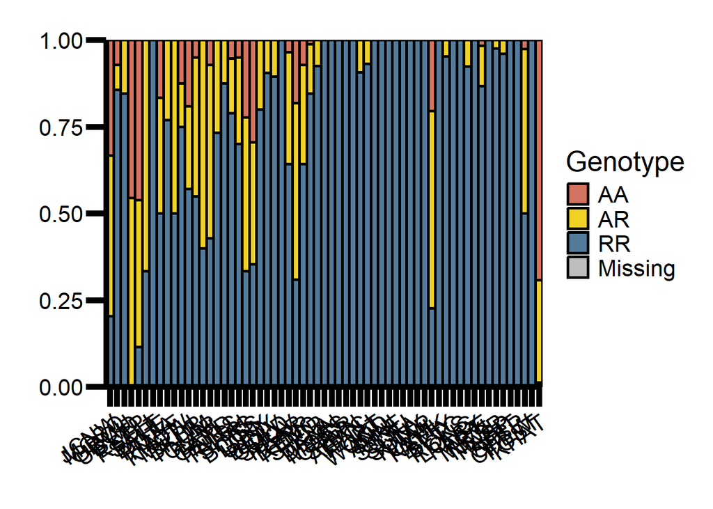

```r
locus_RA$name<-factor(locus_RA$name, levels = c('AA', 'AR', 'RR', 'Missing'))

ggplot(locus_RA, aes(fill = name, y = value, x = location_code)) +
  geom_bar(position = "stack", stat = "identity", width = 1, colour = 'black', size = 1.0, alpha = 0.85) +
  scale_fill_manual(values = c("coral3", "gold2", "steelblue4", "gray70"), name = "Genotype") +
  scale_x_discrete(expand = c(0.0, 0.0)) +
  scale_y_continuous(expand = c(0, 0)) +
  xlab("") +
  ylab("") +
  theme(panel.background = element_blank(),
        text = element_text(family = "sans"),
        plot.margin = margin(1, 0.5, 0.5, 0.5, "cm"),
        legend.title = element_text(size = 20),
        legend.text = element_text(size = 16),
        axis.line = element_line(size = 2, color = 'black'),
        axis.ticks = element_line(size = 2, color = 'black'),
        axis.ticks.length = unit(0.5, "cm"),
        axis.text.x = element_text(angle = 35, vjust = 0.95, hjust=1, size = 16, colour = 'black'),
        axis.text.y = element_text(size = 16, colour = 'black')
  )
```

Compare temporal changes in genotype frequency within the 13 locations with past (i.e., 2000, 2003, 2006) and contemporary (i.e., 2015 - 2019) sampling (Supplementary Fig. 4). Will start with past sampling first.

```r
old_sites <- full_markerset %>%
  filter(c(Year_Collected == "2000" | Year_Collected == "2003" | Year_Collected == "2006"))
```

Subset the dataframe to the sampling metadata and the Omy_RAD15709-53 marker.

```r
old_53 <- old_sites[, c(1:27, 176)]    ##Grab metadata in columns 1:27 and the marker Omy_RAD15709-53 in column 176
```

Put the rows of the dataframe in order according to the location number.

```r
old_53<-old_53[order(as.numeric(as.character(old_53$location_number))), ]

##Set order of locations##
old_53$location_code<-factor(old_53$location_code, levels = unique(old_53$location_code))
```

Calculate genotypic frequencies for early (EE), heterozygous (EL), and late (LL) genotypes in past sampling events.

```r
old_ws_summary<-old_53 %>%
  group_by(location_code) %>%
  summarize(n = n(), EE = sum(`Omy_RAD15709-53` == "AA") / n, EL = sum(`Omy_RAD15709-53` == "GA") / n, LL = sum(`Omy_RAD15709-53` == "GG") / n, Missing = sum(`Omy_RAD15709-53` == "00") / n)


old_ws_summary %<>%
  pivot_longer(cols = c(EE, EL, LL, Missing))
```

Make the genotypic frequency barplot (Fig. S4. C).

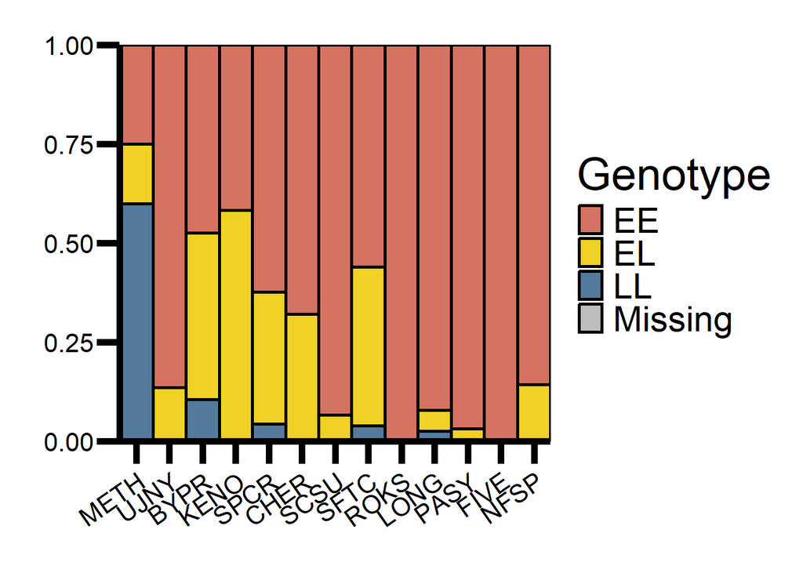

```r
ggplot(old_ws_summary, aes(fill = name, y = value, x = location_code)) +
  geom_bar(position = "stack", stat = "identity", width = 1, colour = 'black', size = 1.0, alpha = 0.85) +
  scale_fill_manual(values = c("coral3", "gold2", "steelblue4", "gray70"), name = "Genotype") +
  scale_x_discrete(expand = c(0.0, 0.0)) +
  scale_y_continuous(expand = c(0, 0)) +
  xlab("") +
  ylab("") +
  theme(panel.background = element_blank(),
        text = element_text(family = "sans"),
        plot.margin = margin(1, 0.5, 0.5, 0.5, "cm"),
        legend.title = element_text(size = 28),
        legend.text = element_text(size = 22),
        axis.line = element_line(size = 2, color = 'black'),
        axis.ticks = element_line(size = 2, color = 'black'),
        axis.ticks.length = unit(0.5, "cm"),
        axis.text.x = element_text(angle = 35, vjust = 0.95, hjust=1, size = 16, colour = 'black'),
        axis.text.y = element_text(size = 16, colour = 'black')
  )
```

Subset the 13 paired contemporary sites. Spring Creek was sampled in the Fall and Summer seasons of the same year. Combine samples from Fall and Summer contemporary sampling.

```r
##combine Spring Creek samples##
contemp_full_markerset %<>%
  mutate(location_code = case_when(location_code %in% c('SCFA') ~ 'SCSU',
                                   TRUE ~ as.character(location_code)
))
##Subset paired contemporary sites.
paired_contemporary_sites<-subset(contemp_full_markerset, contemp_full_markerset$location_code == "METH" | contemp_full_markerset$location_code == "UJNY" | contemp_full_markerset$location_code == "BYPR" | contemp_full_markerset$location_code == "KENO" | contemp_full_markerset$location_code == "SPCR" | contemp_full_markerset$location_code == "CHER" | contemp_full_markerset$location_code == "SCSU" | contemp_full_markerset$location_code == "SFTC" | contemp_full_markerset$location_code == "ROKS" |
                                    contemp_full_markerset$location_code == "PASY" | contemp_full_markerset$location_code == "LONG" | contemp_full_markerset$location_code == "FIVE" | contemp_full_markerset$location_code == "NFSP")
```

Subset the dataframe to the sampling metadata and the Omy_RAD15709-53 marker.

```r
paired_contemp_53 <- paired_contemporary_sites[, c(1:27, 176)]    ##Grab metadata in columns 1:27 and the marker Omy_RAD15709-53 in column 176
```

Put the rows of the dataframe in order according to the location number.

```r
paired_contemp_53<-paired_contemp_53[order(as.numeric(as.character(paired_contemp_53$location_number))), ]

##Set order of locations##
paired_contemp_53$location_code<-factor(paired_contemp_53$location_code, levels = unique(paired_contemp_53$location_code))
```

Calculate genotypic frequencies for early (EE), heterozygous (EL), and late (LL) genotypes in contepemporary sampling events.

```r
pc_summary<-paired_contemp_53 %>%
  group_by(location_code) %>%
  summarize(n = n(), EE = sum(`Omy_RAD15709-53` == "AA") / n, EL = sum(`Omy_RAD15709-53` == "GA") / n, LL = sum(`Omy_RAD15709-53` == "GG") / n, Missing = sum(`Omy_RAD15709-53` == "00") / n)

pc_summary %<>%
  pivot_longer(cols = c(EE, EL, LL, Missing))
```

Make the genotypic frequency barplot (Fig. S4. D).

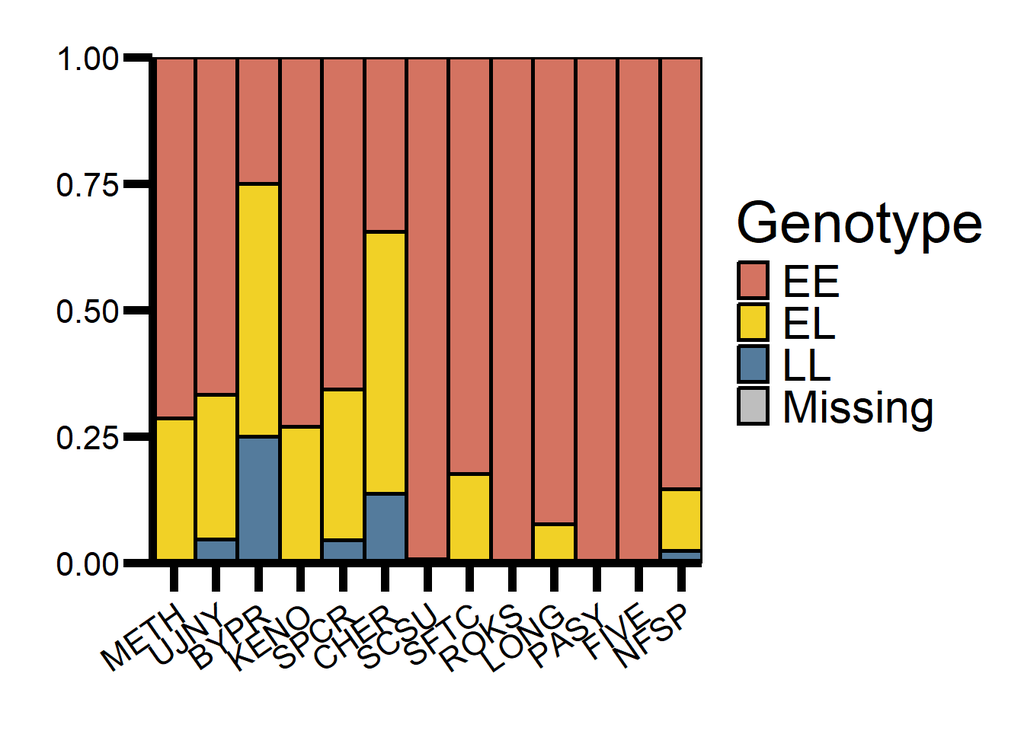

```r
ggplot(pc_summary, aes(fill = name, y = value, x = location_code)) +
  geom_bar(position = "stack", stat = "identity", width = 1, colour = 'black', size = 1.0, alpha = 0.85) +
  scale_fill_manual(values = c("coral3", "gold2", "steelblue4", "gray70"), name = "Genotype") +
  scale_x_discrete(expand = c(0.0, 0.0)) +
  scale_y_continuous(expand = c(0, 0)) +
  xlab("") +
  ylab("") +
  theme(panel.background = element_blank(),
        text = element_text(family = "sans"),
        plot.margin = margin(1, 0.5, 0.5, 0.5, "cm"),
        legend.title = element_text(size = 28),
        legend.text = element_text(size = 22),
        axis.line = element_line(size = 2, color = 'black'),
        axis.ticks = element_line(size = 2, color = 'black'),
        axis.ticks.length = unit(0.5, "cm"),
        axis.text.x = element_text(angle = 35, vjust = 0.95, hjust=1, size = 16, colour = 'black'),
        axis.text.y = element_text(size = 16, colour = 'black')
  )
```

Now compare past and contemporary genotype frequencies for anadramous (AA), heterozygous (AR), and resident (RR) genotypes at Omy5-24370.

```r
old_24370<-old_sites[, c(1:27, 97)]   ##Grab metadata in columns 1:27 and the marker Omy5-24370 in column 97
```

Put the rows of the dataframe in order according to the location number.

```r
old_24370<-old_24370[order(as.numeric(as.character(old_24370$location_number))), ]

##Set order of locations##

old_24370$location_code<-factor(old_24370$location_code, levels = unique(old_24370$location_code))
```

Calculate genotype frequencies for anadramous (AA), heterozygous (AR), and resident (RR) genotypes in past sampling.

```r
old_RA<-old_24370 %>%
  group_by(location_code) %>%
  summarize(n = n(), RR = sum(OmyR24370 == "GG") / n, AR = sum(OmyR24370 == "GA") / n, AA = sum(OmyR24370 == "AA") / n, Missing = sum(OmyR24370 == "00") / n)

old_RA %<>%
  pivot_longer(cols = c(RR, AR, AA, Missing))
```

Set order of genotypes and make the genotypic frequency barplot (Fig. S4. A).

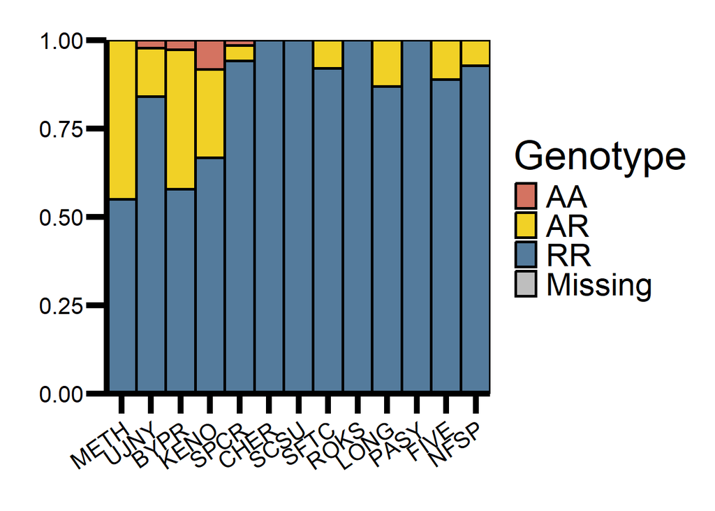

```r
old_RA$name<-factor(old_RA$name, levels = c('AA', 'AR', 'RR', 'Missing'))

ggplot(old_RA, aes(fill = name, y = value, x = location_code)) +
  geom_bar(position = "stack", stat = "identity", width = 1, colour = 'black', size = 1.0, alpha = 0.85) +
  scale_fill_manual(values = c("coral3", "gold2", "steelblue4", "gray70"), name = "Genotype") +
  scale_x_discrete(expand = c(0.0, 0.0)) +
  scale_y_continuous(expand = c(0, 0)) +
  xlab("") +
  ylab("") +
  theme(panel.background = element_blank(),
        text = element_text(family = "sans"),
        plot.margin = margin(1, 0.5, 0.5, 0.5, "cm"),
        legend.title = element_text(size = 28),
        legend.text = element_text(size = 22),
        axis.line = element_line(size = 2, color = 'black'),
        axis.ticks = element_line(size = 2, color = 'black'),
        axis.ticks.length = unit(0.5, "cm"),
        axis.text.x = element_text(angle = 35, vjust = 0.95, hjust=1, size = 16, colour = 'black'),
        axis.text.y = element_text(size = 16, colour = 'black')
  )
```

Subset the 13 paired contemporary sites.

```r
paired_contemp_24370<-paired_contemporary_sites[, c(1:27, 97)]   ##Grab metadata in columns 1:27 and the marker Omy5-24370 in column 97
```

Put the rows of the dataframe in order according to the location number.

```r
paired_contemp_24370<-paired_contemp_24370[order(as.numeric(as.character(paired_contemp_24370$location_number))), ]

##Set order of locations##
paired_contemp_24370$location_code<-factor(paired_contemp_24370$location_code, levels = unique(paired_contemp_24370$location_code))
```

Calculate genotype frequencies for anadramous (AA), heterozygous (AR), and resident (RR) genotypes in contemporary sampling.

```r
contemp_RA<-paired_contemp_24370 %>%
  group_by(location_code) %>%
  summarize(n = n(), RR = sum(OmyR24370 == "GG") / n, AR = sum(OmyR24370 == "GA") / n, AA = sum(OmyR24370 == "AA") / n, Missing = sum(OmyR24370 == "00") / n)

contemp_RA %<>%
  pivot_longer(cols = c(RR, AR, AA, Missing))
```

Set order of genotypes and make the genotypic frequency barplot (Fig. S4. B).

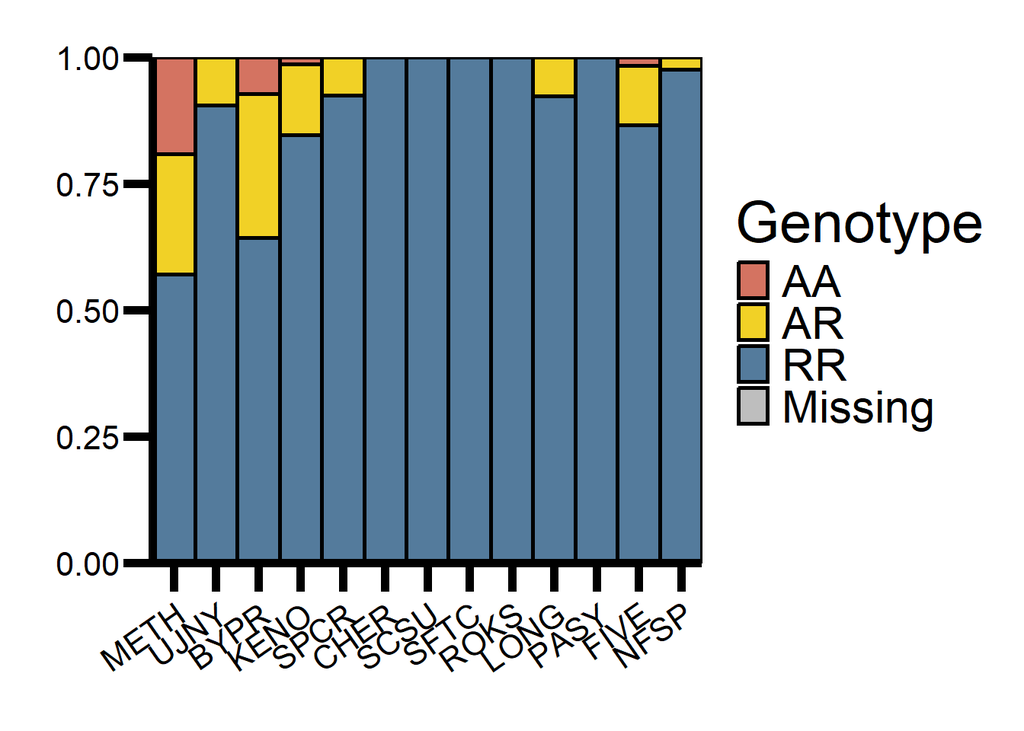

```r
contemp_RA$name<-factor(contemp_RA$name, levels = c('AA', 'AR', 'RR', 'Missing'))

ggplot(contemp_RA, aes(fill = name, y = value, x = location_code)) +
  geom_bar(position = "stack", stat = "identity", width = 1, colour = 'black', size = 1.0, alpha = 0.85) +
  scale_fill_manual(values = c("coral3", "gold2", "steelblue4", "gray70"), name = "Genotype") +
  scale_x_discrete(expand = c(0.0, 0.0)) +
  scale_y_continuous(expand = c(0, 0)) +
  xlab("") +
  ylab("") +
  theme(panel.background = element_blank(),
        text = element_text(family = "sans"),
        plot.margin = margin(1, 0.5, 0.5, 0.5, "cm"),
        legend.title = element_text(size = 28),
        legend.text = element_text(size = 22),
        axis.line = element_line(size = 2, color = 'black'),
        axis.ticks = element_line(size = 2, color = 'black'),
        axis.ticks.length = unit(0.5, "cm"),
        axis.text.x = element_text(angle = 35, vjust = 0.95, hjust=1, size = 16, colour = 'black'),
        axis.text.y = element_text(size = 16, colour = 'black')
  )
```

Evaluate genotype frequencies at seven adult run timing markers on chromosome 28 across contemporary samples collected in the years 2015 - 2019 (Supplementary Figure 3). Note, I think this is clunky but necessarily so. Each marker has different genotypes (e.g., AA, TT, CC, GG) that are associated with early or late return timing. Consequently, need to write conditions for each marker. Prepare dataframes for each marker.

```r
##Chr28-11667578##
Chr28_1<-contemp_full_markerset[, c(1:27, 31)]
##put rows in order of location number##
Chr28_1<-Chr28_1[order(as.numeric(as.character(Chr28_1$location_number))), ]
##Set order of locations##
Chr28_1$location_code<-factor(Chr28_1$location_code, levels = unique(Chr28_1$location_code))

##Omy_RAD-53
omy_53<-contemp_full_markerset[, c(1:27, 176)]
##put rows in order of location number##
omy_53<-omy_53[order(as.numeric(as.character(omy_53$location_number))), ]
##Set order of locations##
omy_53$location_code<-factor(omy_53$location_code, levels = unique(omy_53$location_code))

##Chr28_11676622##
chr28_2<-contemp_full_markerset[, c(1:27, 32)]
##put rows in order of location number##
chr28_2<-chr28_2[order(as.numeric(as.character(chr28_2$location_number))), ]
##Set order of locations##
chr28_2$location_code<-factor(chr28_2$location_code, levels = unique(chr28_2$location_code))

##Chr28_11683204##
chr28_3<-contemp_full_markerset[, c(1:27, 33)]
##put rows in order of location number##
chr28_3<-chr28_3[order(as.numeric(as.character(chr28_3$location_number))), ]
##Set order of locations##
chr28_3$location_code<-factor(chr28_3$location_code, levels = unique(chr28_3$location_code))

##Chr28_11702210##
chr28_4<-contemp_full_markerset[, c(1:27, 34)]
##put rows in order of location number##
chr28_4<-chr28_4[order(as.numeric(as.character(chr28_4$location_number))), ]
##Set order of locations##
chr28_4$loction_code<-factor(chr28_4$location_code, levels = unique(chr28_4$location_code))

##Omy_GREB1_05##
chr28_5<-contemp_full_markerset[, c(1:27, 154)]
##put rows in order of location number##
chr28_5<-chr28_5[order(as.numeric(as.character(chr28_5$location_number))), ]
##Set order of locations##
chr28_5$location_code<-factor(chr28_5$location_code, levels = unique(chr28_5$location_code))

##Chr28_11658853##
chr28_6<-contemp_full_markerset[, c(1:27, 30)]
##put rows in order of location number##
chr28_6<-chr28_6[order(as.numeric(as.character(chr28_6$location_number))), ]
##Set order of locations##
chr28_6$location_code<-factor(chr28_6$location_code, levels = unique(chr28_6$location_code))
```

Calculate genotype frequencies for each marker based on their unique polarization.

```r
locus_1<-Chr28_1 %>%   ##Chr28_11667578##
  group_by(location_code) %>%
  summarize(n = n(), EE = sum(Chr28_11667578 == "TT") / n, EL = sum(Chr28_11667578 == "TC") / n, LL = sum(Chr28_11667578 == "CC") / n, Missing = sum(Chr28_11667578 == "00") / n)
locus_1 %<>%
  pivot_longer(cols = c(EE, EL, LL, Missing))
locus_1$locus<-rep("Chr28_11667578", times = nrow(locus_1))

locus_2<-omy_53 %>%  ##Omy_RAD-53
  group_by(location_code) %>%
  summarize(n = n(), EE = sum(`Omy_RAD15709-53` == "AA") / n, EL = sum(`Omy_RAD15709-53` == "GA") / n, LL = sum(`Omy_RAD15709-53` == "GG") / n, Missing = sum(`Omy_RAD15709-53` == "00") / n)
locus_2 %<>%
  pivot_longer(cols = c(EE, EL, LL, Missing))
locus_2$locus<-rep("Omy_RAD15709-53", times = nrow(locus_2))

locus_3<-chr28_2 %>%  ##Chr28_11676622##
  group_by(location_code) %>%
  summarize(n = n(), EE = sum(Chr28_11676622 == "TT") / n, EL = sum(Chr28_11676622 == "TG") / n, LL = sum(Chr28_11676622 == "GG") / n, Missing = sum(Chr28_11676622 == "00") / n)
locus_3 %<>%
  pivot_longer(cols = c(EE, EL, LL, Missing))
locus_3$locus<-rep("Chr28_11676622", times = nrow(locus_3))

locus_4<-chr28_3 %>%  ##Chr28_11683204##
  group_by(location_code) %>%
  summarize(n = n(), EE = sum(Chr28_11683204 == "GG") / n, EL = sum(Chr28_11683204 == "GT") / n, LL = sum(Chr28_11683204 == "TT") / n, Missing = sum(Chr28_11683204 == "00") / n)
locus_4 %<>%
  pivot_longer(cols = c(EE, EL, LL, Missing))
locus_4$locus<-rep("Chr28_11683204", times = nrow(locus_4))

locus_5<-chr28_4 %>%   ##Chr28_11702210##
  group_by(location_code) %>%
  summarize(n = n(), EE = sum(Chr28_11702210 == "TT") / n, EL = sum(Chr28_11702210 == "TG") / n, LL = sum(Chr28_11702210 == "GG") / n, Missing = sum(Chr28_11702210 == "00") / n)
locus_5 %<>%
  pivot_longer(cols = c(EE, EL, LL, Missing))
locus_5$locus<-rep("Chr28_11702210", times = nrow(locus_5))

locus_6<-chr28_5 %>%   ##Omy_GREB1_05##
  group_by(location_code) %>%
  summarize(n = n(), EE = sum(Omy_GREB1_05 == "TT") / n, EL = sum(Omy_GREB1_05 == "TG") / n, LL = sum(Omy_GREB1_05 == "GG") / n, Missing = sum(Omy_GREB1_05 == "00") / n)
locus_6 %<>%
  pivot_longer(cols = c(EE, EL, LL, Missing))
locus_6$locus<-rep("Omy_GREB1_05", times = nrow(locus_6))

locus_7<-chr28_6 %>%    ##Chr28_11658853##
  group_by(location_code) %>%
  summarize(n = n(), EE = sum(Chr28_11658853 == "AA") / n, EL = sum(Chr28_11658853 == "AC") / n, LL = sum(Chr28_11658853 == "CC") / n, Missing = sum(Chr28_11658853 == "00") / n)
locus_7 %<>%
  pivot_longer(cols = c(EE, EL, LL, Missing))
locus_7$locus<-rep("Chr28_11658853", times = nrow(locus_7))

all_loci<-rbind(locus_1, locus_2, locus_3, locus_4, locus_5, locus_6, locus_7)
all_loci$locus<-as.character(all_loci$locus)
all_loci$locus<-factor(all_loci$locus, levels = c("Omy_GREB1_05", "Chr28_11658853", "Chr28_11667578", "Omy_RAD15709-53", "Chr28_11676622", "Chr28_11683204", "Chr28_11702210"))

kable(all_loci[1:10, ], col.names = c("location code", "n", "genotype", "Freq", "marker"))
```

| location code | n | genotype | Freq | marker |
| --- | --- | --- | --- | --- |
| JCNW | 54 | EE | 0.9629630 | Chr28_11667578 |
| JCNW | 54 | EL | 0.0370370 | Chr28_11667578 |
| JCNW | 54 | LL | 0.0000000 | Chr28_11667578 |
| JCNW | 54 | Missing | 0.0000000 | Chr28_11667578 |
| MOSQ | 14 | EE | 0.0000000 | Chr28_11667578 |
| MOSQ | 14 | EL | 0.0714286 | Chr28_11667578 |
| MOSQ | 14 | LL | 0.9285714 | Chr28_11667578 |
| MOSQ | 14 | Missing | 0.0000000 | Chr28_11667578 |
| GROU | 13 | EE | 0.0000000 | Chr28_11667578 |
| GROU | 13 | EL | 0.3076923 | Chr28_11667578 |

Make the genotype frequency barplot for the seven markers within all 60 contemporary sampling locations (Fig S3). Note, the plot created in this R markdown file is compressed. Exporting will make the plot larger and all the locations will be visible.

[figure not shown]

```r
ggplot(all_loci, aes(fill = name, y = value, x = locus)) +
  geom_bar(position = "stack", stat = "identity", width = 1, colour = 'black', size = 1) +
  scale_fill_manual(values = c("coral3", "gold2", "steelblue4", "gray70"), name = "Genotype") +
  scale_x_discrete(expand = c(0.05, 0.05)) +
  scale_y_continuous(expand = c(0, 0), breaks = c(0.0, 0.5, 1.0)) +
  xlab("") +
  ylab("") +
  facet_wrap(vars(location_code), ncol = 10) +
  theme(panel.background = element_blank(),
        strip.background = element_rect(color = "black", linewidth = 2, fill = "white"),
        text = element_text(family = "sans"),
        strip.text.x = element_text(size = 12, face = "bold"),
        plot.margin = margin(1, 0.5, 0.5, 0.5, "cm"),
        legend.title = element_text(size = 16),
        legend.text = element_text(size = 12),
        axis.line = element_line(size = 2, color = 'black'),
        axis.ticks = element_line(size = 2, color = 'black'),
        axis.ticks.length = unit(0.5, "cm"),
        axis.text.x = element_text(angle = 90, vjust = 0.5, hjust= 1, size = 16, colour = 'black'),
        axis.text.y = element_text(size = 16, colour = 'black')
  )
```